# Gráficos

Jordan Golubov y José Arévalo

2026-04-11

## Gráficos en R

Uno de los elementos más imrpotantes en el análisis de datos es la *visualización* de los datos. Esto implica que de entrada debemos tener una idea de cuál sería la variable dependiente, la independiente, y una aproximación del patrón que esperamos de los datos. Esto nos ayuda a identificar el eje de las $x$ de la $y$ y una idea del _tipo_de gráfica que vamos a obtener.

Uno de los atributos más poderosos en **R** son los gráficos. Esto no quiere decir que sean fáciles sino que existen una gran cantidad de éstas. En términos generales, dependiendo del tipo de variable es el tipo de gráfico que genera **R**. Por ejemplo, si tenemos dos variables se va a generar una gráfica de puntos, si una de las variables es un factor entonces se genera una gráfica de caja y bigote.

Nosotros vamos a usar y explorar la función `plot()`. **R** tiene un formato incluido para graficar que es la función `plot()`. También hay paquetes que utilizan diferentes formatos como por ejemplo *ggplot2*.

Primero vamos a ver cómo es que funciona, para fines prácticos se puede utilizar como argumentos una *x* y una *y*, es decir una variable independiente y una dependiente.

Con los datos de la diversidades podemos hacer una gráfica de las parcelas de BCI y las diversidades. En este caso las *x* es asumida como el índice de la parcela y *y* es el índice de diversidad **H**.

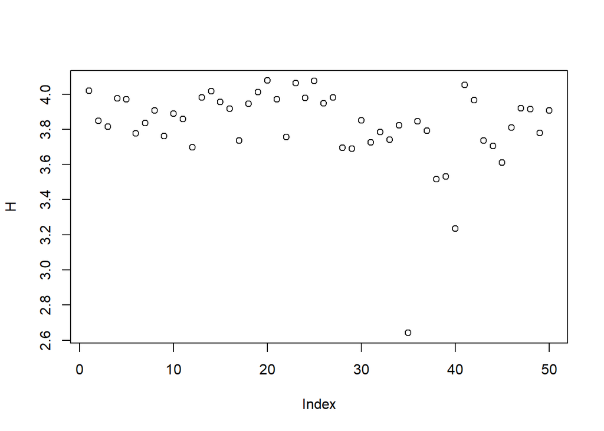

```r
library(ggplot2)
library(dplyr)
library(vegan)
data(BCI)
H <- diversity(BCI, index = "shannon")
plot(H)
```

La función `plot()` tiene diferentes argumentos. Por ejemplo, si queremos cambiar el nombre de los ejes usamos los argumentos `xlab= ""` y `ylab= ""`para *x* y *y* respectivamente.

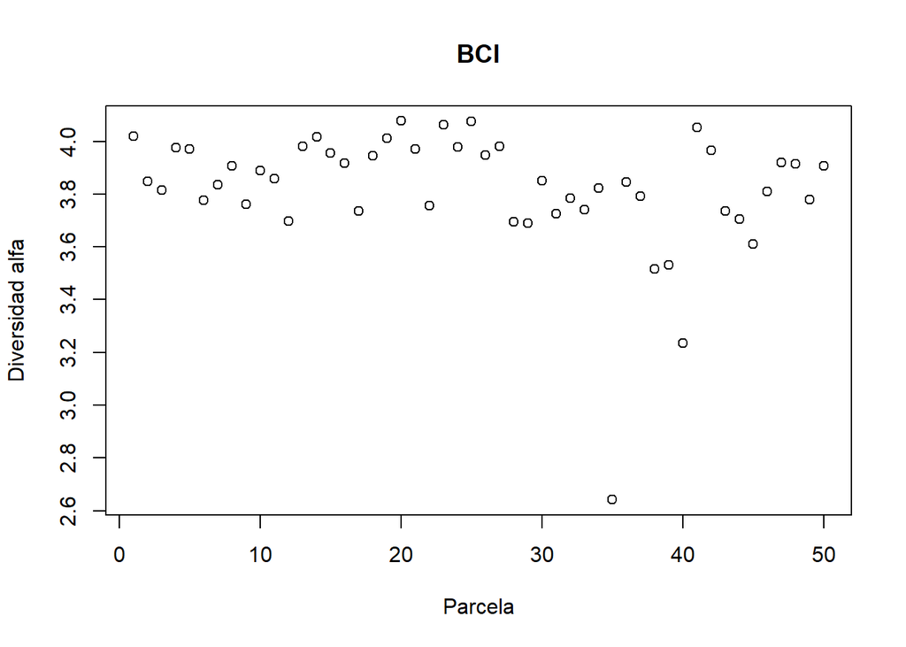

```r
plot(H, ylab = "Diversidad alfa", xlab = "Parcela", main = "BCI")
```

Las escalas de los ejes se pueden cambiar usando los argumentos `xlim` y `ylim` para *x* y *y*. Al se un rango, este se tiene que escribir en forma concatenada, es decir `ylim=c(3.2,4)`, un rango de eje *y* del 3.2 a 4.

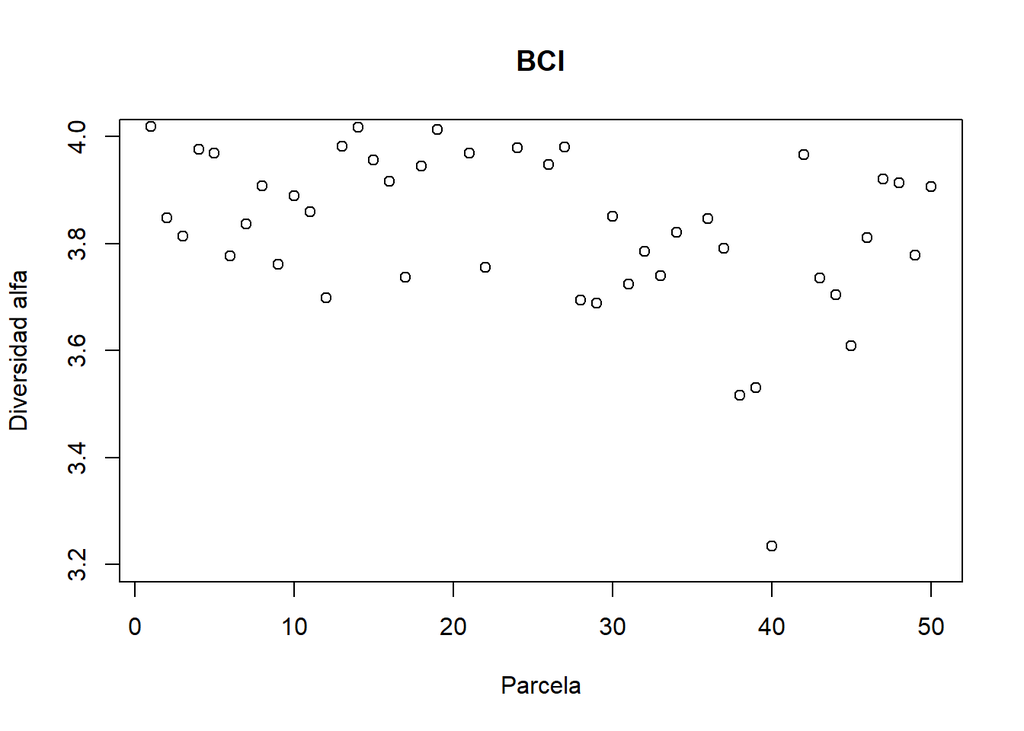

```r
plot(H, ylab = "Diversidad alfa", xlab = "Parcela", main = "BCI", ylim = c(3.2,4))
```

Nótese que los valores menores a 3.2 ya no aparece en la gráfica.

**R** tiene como 3 tipos básicos de gráfica, pero la relación entre la x y la y depende en gran medida del tipo de variable explicatoria (la x) que tienes. Puedes tener una sola variable, dos variables o multivariables. Cuando la variable explicatoria es continua se hace una gráfica de puntitos, cuando es categórica es una de caja y bigote o una de barras.

A los gráficos de **R** se les puede añadir un sin fin de atributos. Ya se tiene la gráfica anterior, se le puede poner un poco de texto, una línea, un punto, etc. El principio fundamental es que todo tiene coordenadas dentro del gráfico.

1. **points** para añadir puntos
2. **lines** para añadir líneas
3. **text** para añadir texto

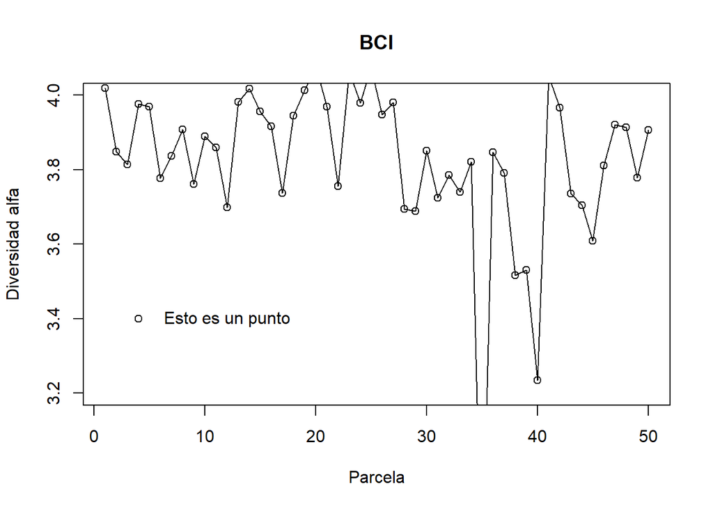

```r
plot(H, ylab = "Diversidad alfa", xlab = "Parcela", main = "BCI", ylim = c(3.2,4))
points(4,3.4)
lines(H)
text(12,3.4,"Esto es un punto")
```

Modifique la posición del texto en la gráfica para descubrir cual es la regla que utiliza **R** para el texto, también modifique la longitud del texto si la primera opción no es clara.

## Parámetros dentro de plot

Tamaño del texto y del símbolo se usa **cex=**

`cex`: Número que indica la cantidad de por el cual es símbolo escalado. Por ejemplo 1.5 = 50% más grande

`cex.axis`: Aumento de los ejes

`cex.lab`: Aumento de las etiquetas de las etiquetas de los ejes x y y

`cex.main`: Aumento del título

Ejemplo

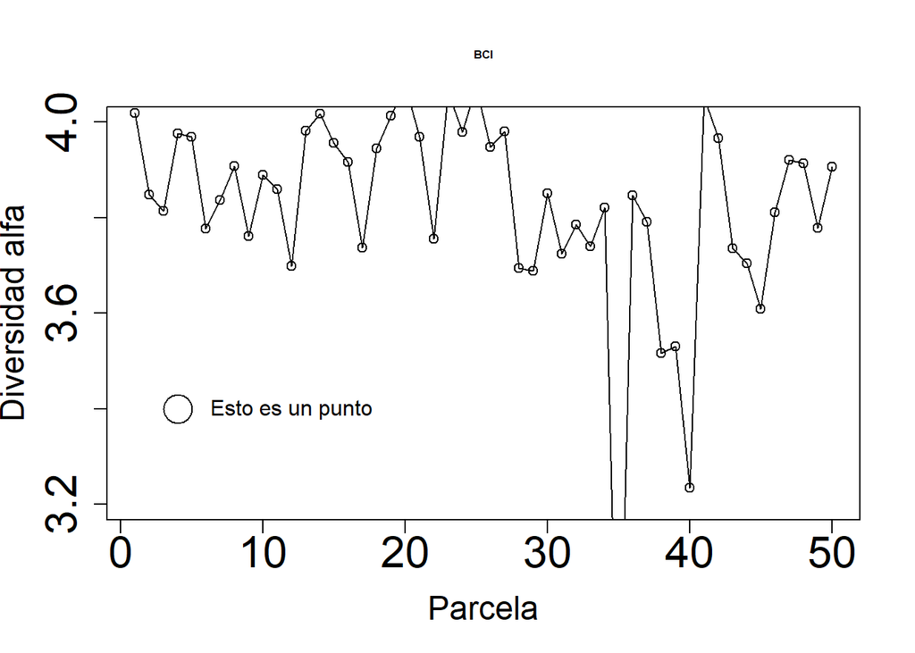

```r
plot(H, ylab = "Diversidad alfa", xlab = "Parcela", main = "BCI", ylim = c(3.2,4), cex.axis=2, cex.lab= 1.5, cex.main= 0.5)
points(4,3.4, cex=3)
lines(H)
text(12,3.4,"Esto es un punto")
```

## Símbolos

Los símbolos se cambian con el argumento **pch**

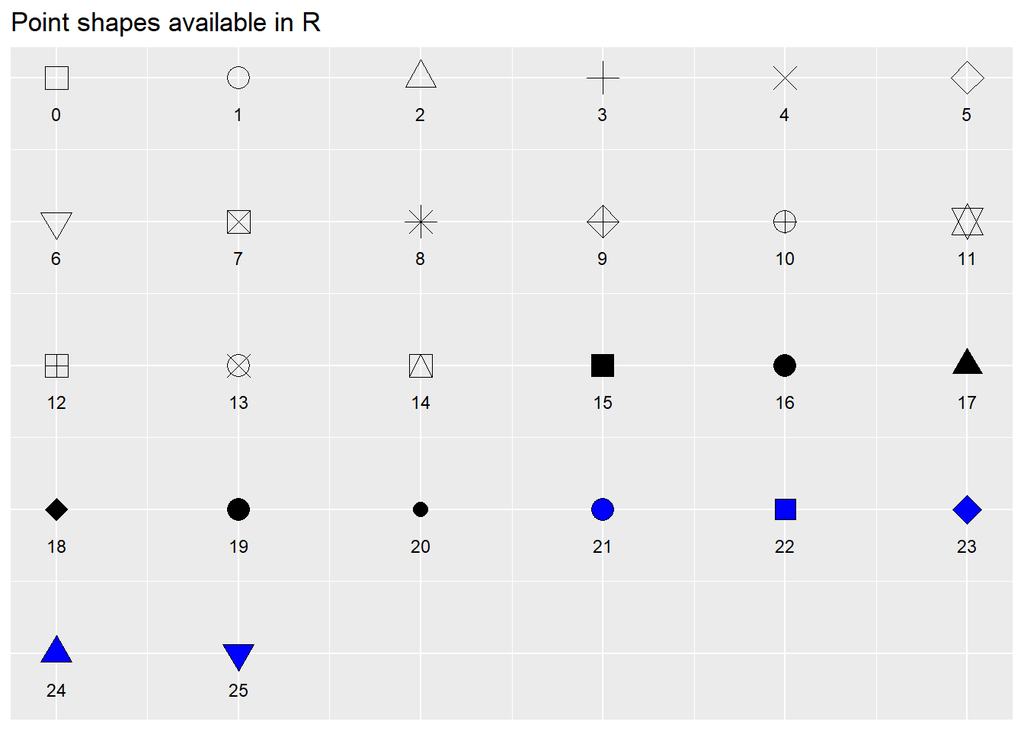

```r
ggpubr::show_point_shapes()
```

El tipo de línea se modifica con el argumento `lty=`

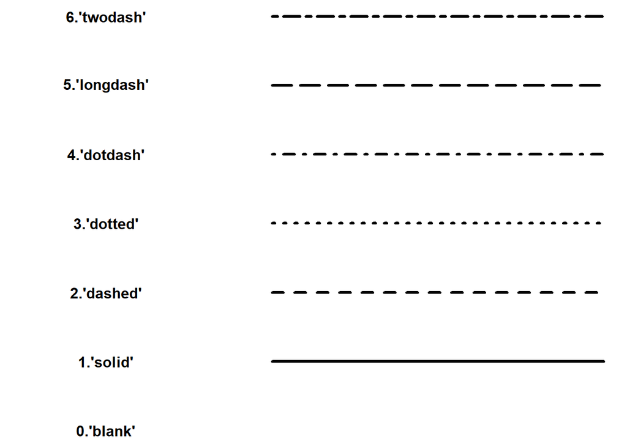

## Colores

Los colores se pueden especificar de varias formas

1. `col`: El color para graficar
2. `col.axis`: El color de las anotaciones de los ejes
3. `col.lab`: Color de las etiquetas x y y
4. `col.main`: color del título
5. `bg`: el color del fondo de la gráfica

## Guardando gráficos

Para guardar una figura en **R** es un proceso que hace tres pasos:

1. Abra una conexión a una archivo mediante el comando de figuras que puede ser de diferentes formatos (png, tiff, pdf, jpg, eps)
2. Genera la gráfica
3. Guarda la gráfica cerrando para grabarla a disco

Mientras no cierres la gráfica no la graba a disco.

### **Rstudio**

En **RStudio** es muy sencillo hacer esto, simplemente se exporta del tamaño y formato que quiere. Internamente **RStudio** realiza los tres pasos mencionados anteriormente.

En **R** podemos poner varias gráficas en una sola hoja. El número de gráficos y la disposición sigue las mismas reglas de renglón y columna, visto con anterioridad. Varias figuras `par(mfrow=c(2,1))` Genera dos gráficas de 2 renglones por una columna `par(mfrow=c(1,2))` Genera dos gráficas de 1 renglón por dos columnas.

## Ejercicio con datos

Vamos a utilizar los datos incluidos en **R** sobre la planta Iris

```r
data(iris)
head(iris, 3)
```

```
##   Sepal.Length Sepal.Width Petal.Length Petal.Width Species
## 1          5.1         3.5          1.4         0.2  setosa
## 2          4.9         3.0          1.4         0.2  setosa
## 3          4.7         3.2          1.3         0.2  setosa
```

```r
tail(iris, 3)
```

```
##     Sepal.Length Sepal.Width Petal.Length Petal.Width   Species
## 148          6.5         3.0          5.2         2.0 virginica
## 149          6.2         3.4          5.4         2.3 virginica
## 150          5.9         3.0          5.1         1.8 virginica
```

## Gráficas

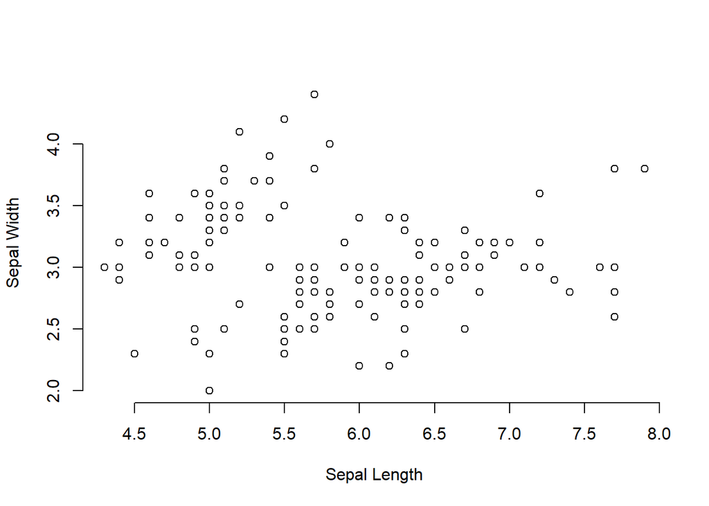

```r
# Default plot pch = 1 (círculo vació)
plot(x = iris$Sepal.Length, y = iris$Sepal.Width, frame = FALSE,
     xlab = "Sepal Length", ylab = "Sepal Width")
```

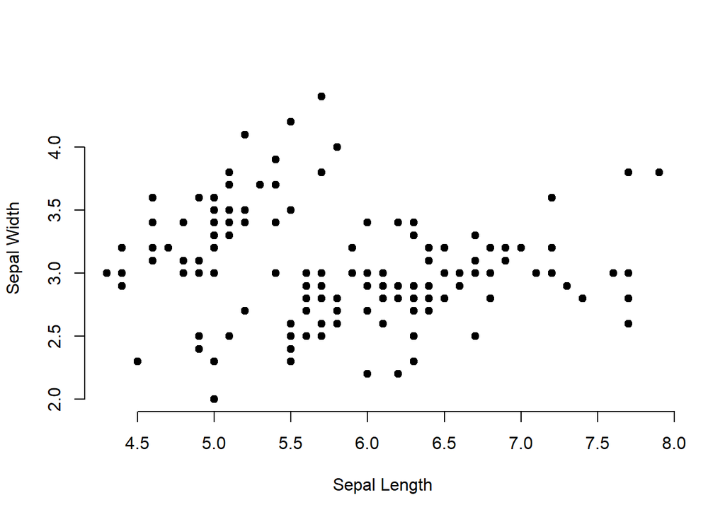

```r
# Change plot symbol to pch = 19 (círculo sólido)
plot(x = iris$Sepal.Length, y = iris$Sepal.Width, frame = FALSE,
     xlab = "Sepal Length", ylab = "Sepal Width",
     pch = 19)
```

Cambiemos algunas cosas:

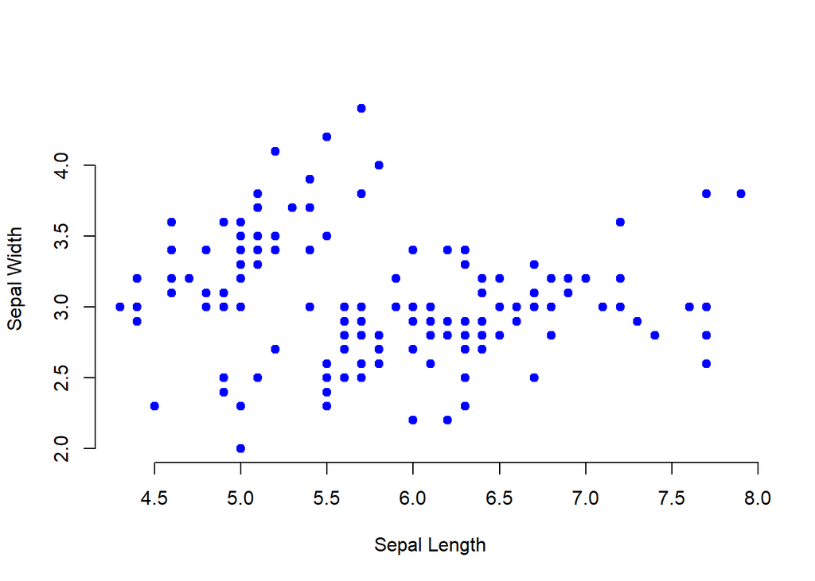

```r
# Cambio de color
plot(x = iris$Sepal.Length, y = iris$Sepal.Width, frame = FALSE,
     xlab = "Sepal Length", ylab = "Sepal Width",
     pch = 19, col = "blue")
```

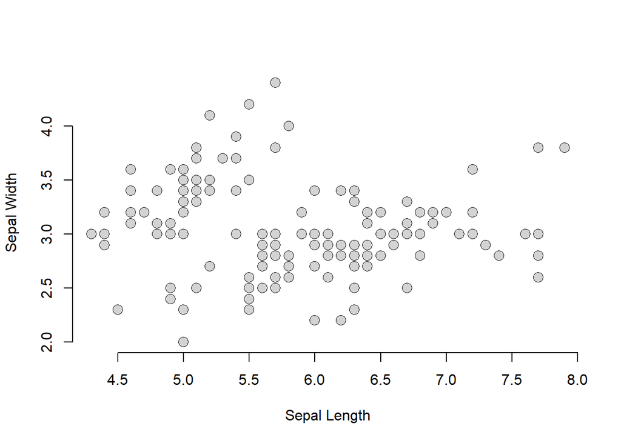

```r
# Usando pch = 21
# Cambiar ancho del borde (lwd), y color de atrás (bg)
plot(x = iris$Sepal.Length, y = iris$Sepal.Width, frame = FALSE,
     xlab = "Sepal Length", ylab = "Sepal Width",
     pch = 21, bg = "lightgray", col = "black",
     lwd = 0.9, cex = 1.5)
```

Ahora la gráfica completa sería algo como un color por especie

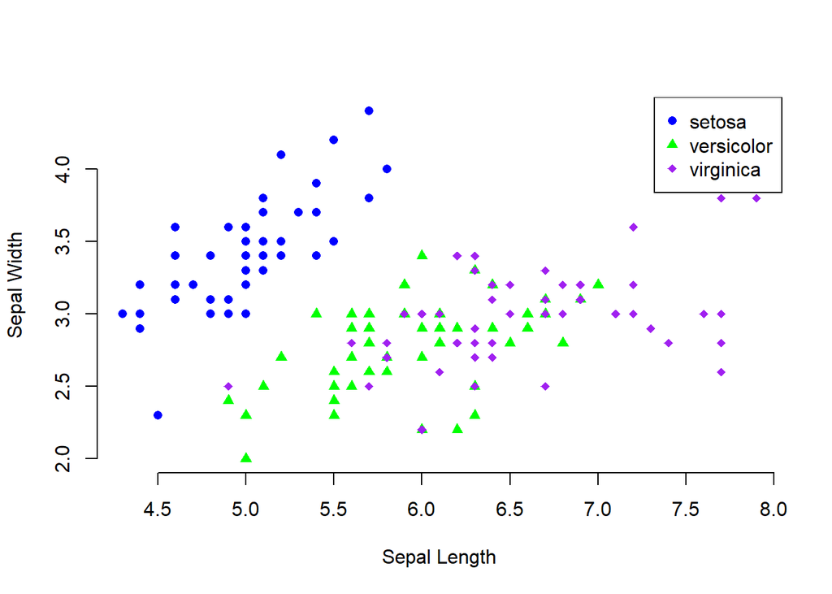

```r
# Definimos los colores para cada una de las especies de iris
colors <- c("blue", "green", "purple")
colors <- colors[as.numeric(iris$Species)]

# Definir formas
shapes = c(16, 17, 18)
shapes <- shapes[as.numeric(iris$Species)]

# Plot
plot(x = iris$Sepal.Length, y = iris$Sepal.Width, frame = FALSE,
     xlab = "Sepal Length", ylab = "Sepal Width",
     col = colors, pch = shapes)
legend("topright", legend = levels(iris$Species),
      col =  c("blue", "green", "purple"),
      pch = c(16, 17, 18) )
```

## Gráficas de factores y variables continuas

Existen varios tipos de gráficos que usamos de manera cotidiana en biología. Las barras y los gráficos que tienen una variable continua y una variable discreta, por ejemplo, con los datos de **iris** queremos saber cómo se comportan las variables de tamaño del pétalo para cada una de las especies.

```r
head(iris,5)
```

```
##   Sepal.Length Sepal.Width Petal.Length Petal.Width Species
## 1          5.1         3.5          1.4         0.2  setosa
## 2          4.9         3.0          1.4         0.2  setosa
## 3          4.7         3.2          1.3         0.2  setosa
## 4          4.6         3.1          1.5         0.2  setosa
## 5          5.0         3.6          1.4         0.2  setosa
```

```r
str(iris)
```

```
## 'data.frame':    150 obs. of  5 variables:
##  $ Sepal.Length: num  5.1 4.9 4.7 4.6 5 5.4 4.6 5 4.4 4.9 ...
##  $ Sepal.Width : num  3.5 3 3.2 3.1 3.6 3.9 3.4 3.4 2.9 3.1 ...
##  $ Petal.Length: num  1.4 1.4 1.3 1.5 1.4 1.7 1.4 1.5 1.4 1.5 ...
##  $ Petal.Width : num  0.2 0.2 0.2 0.2 0.2 0.4 0.3 0.2 0.2 0.1 ...
##  $ Species     : Factor w/ 3 levels "setosa","versicolor",..: 1 1 1 1 1 1 1 1 1 1 ...
```

La variable Species es un factor, ver iris con la función `str()`. Si graficamos el factor con la variable de longitud del pétalo.

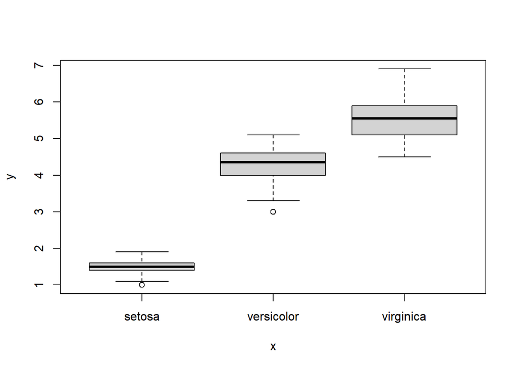

```r
plot(iris$Species,iris$Petal.Length)
```

Nos da un gráfico de caja y bigote. Esto básicamente es el resumen de la base de datos de **iris**.

```r
tapply(iris$Petal.Length,iris$Species, summary)
```

```
## $setosa
##    Min. 1st Qu.  Median    Mean 3rd Qu.    Max.
##   1.000   1.400   1.500   1.462   1.575   1.900
##
## $versicolor
##    Min. 1st Qu.  Median    Mean 3rd Qu.    Max.
##    3.00    4.00    4.35    4.26    4.60    5.10
##
## $virginica
##    Min. 1st Qu.  Median    Mean 3rd Qu.    Max.
##   4.500   5.100   5.550   5.552   5.875   6.900
```

### gráfico stripchart

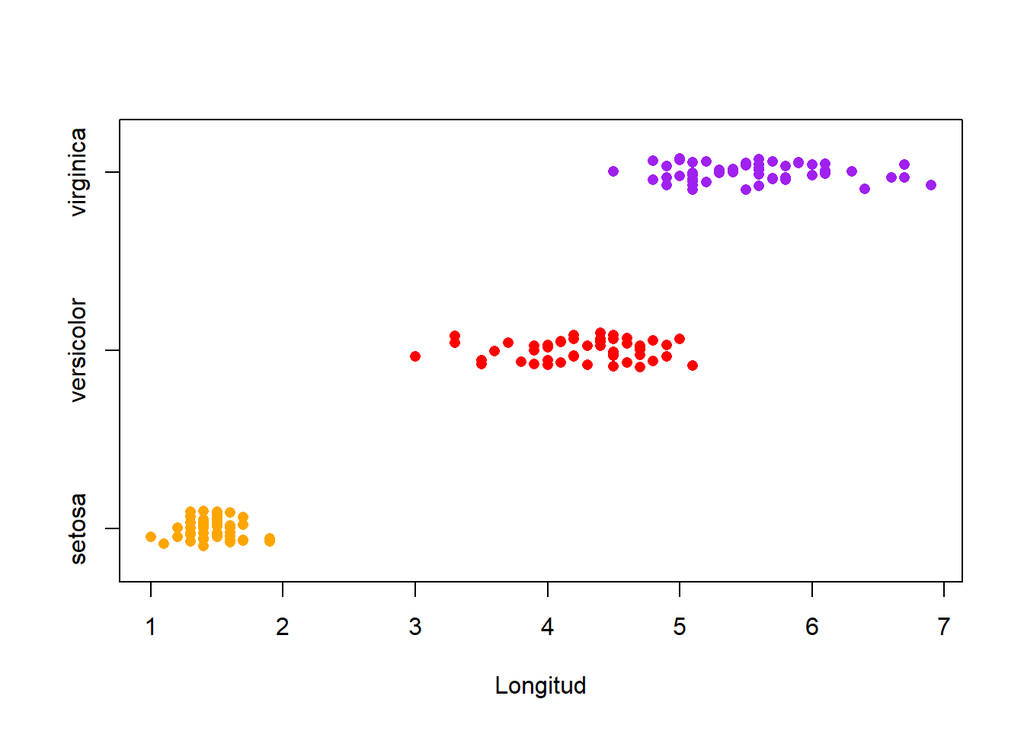

```r
x <- list("setosa"=iris$Petal.Length[1:50], "versicolor"=iris$Petal.Length[51:100], "virginica" = iris$Petal.Length[101:150])

stripchart(x, method="jitter", col=c("orange","red","purple"), pch=16, xlab = "Longitud")
```

También puedes usar una fórmula

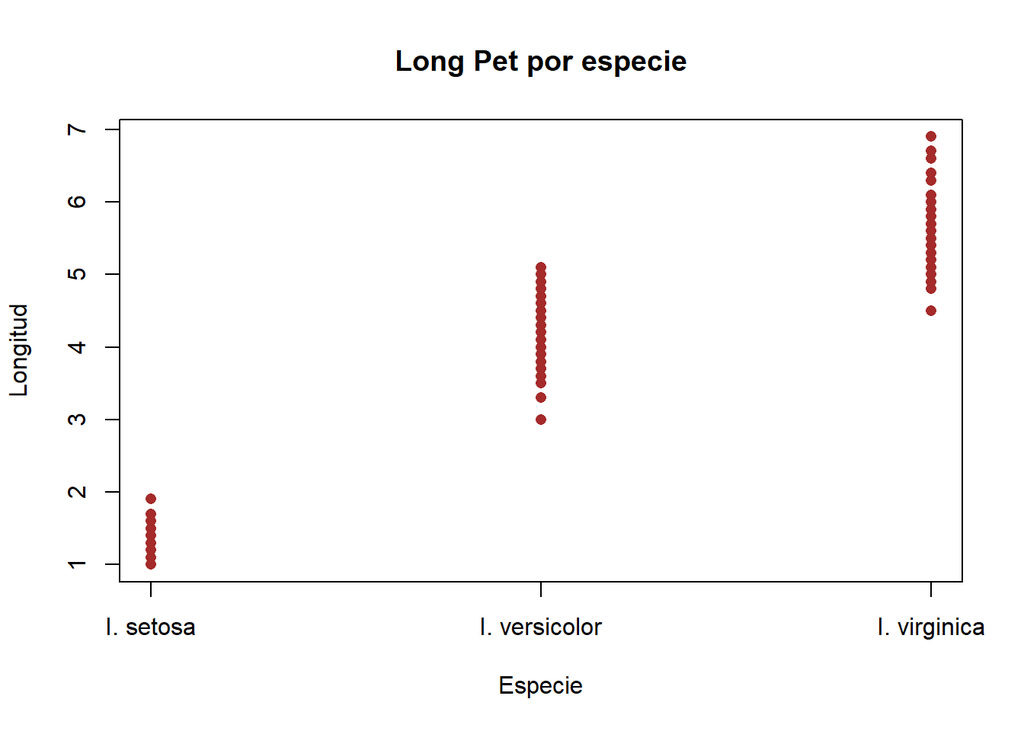

```r
stripchart(iris$Petal.Length~iris$Species,
main="Long Pet por especie",
xlab="Especie",
ylab="Longitud",
col="brown",
group.names=c("I. setosa","I. versicolor","I. virginica"),
vertical=TRUE,
pch=16
)
```

Las gráficas de barras utilizan de entrada un vector con frecuencias. Las frecuencias podemos obtenerlas de la función `table`, por ejemplo, supongamos que tenemos datos de alturas por género.

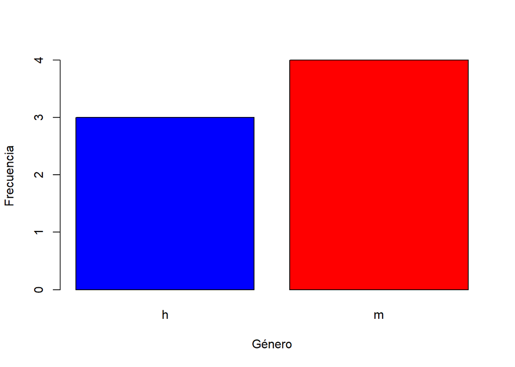

```r
genero.prueba <- c("h","m","m","m","h","h","m")
alturas.prueba <- c(1,3,5,2,6,8,3)

alturas.por.genero <- data.frame(genero.prueba,alturas.prueba)
tabla.genero<- table(alturas.por.genero$genero.prueba)
barplot(tabla.genero, xlab = "Género", ylab = "Frecuencia", col = c("blue", "red"))
```

## El paquete ggplot

El paquete ggplot es una extensión muy flexible para gráficos. Como es parte de los paquetes tidyverse, utiliza dataframes de entrada. El potencial de ggplot es enorme porque se han hecho algunas extensiones útiles que utilizan la base de ggplot. El uso de ggplot tiene una curva de aprendizaje casi vertical, lo que implica que son muchas horas (algunas muy frustrantes) para poder obtener tus primeras gráficas pero los beneficios son enormes.

La sintáxis fundamental de ggplot se compone de la base de datos que debe de ser un dataframe y la asignación de la variable $x$ y la $y$ en lo que denominan la estética o aesthetics defininda como *aes*. Finalmente ggplot funciona añadiendo atributos y capas a la estética. Los datos y la estética **siempre** son la primera línea. Lo que le sigue se van añadiendo con el símbolo de +. El siguiente componente es el co mponente geomético, y asignarle la relación entre las $x$, y las $y$, podemos añadir el tipo de gráfico que se quiere, puntos, caja y bigote, barras, etc. Además de estos dos componetes básicos podemos añadirle capas de diferentes cosas, leyendas, ejes, líneas, texto entre otros usando el símbolo +

Si usamos los datos de *A. ornatum* podemos empezar a explorar los beneficios de ggplot.

```r
Aornatum <- read.csv("Aornatum.csv", header=TRUE)
```

Entonces debemos recordar 3 cosas principales: 1. Definir el dataframe 2. Definir las variables de aesthetics $x$ y $y$ 3. Declarar el tipo de gráfico que se quiere plasmar.

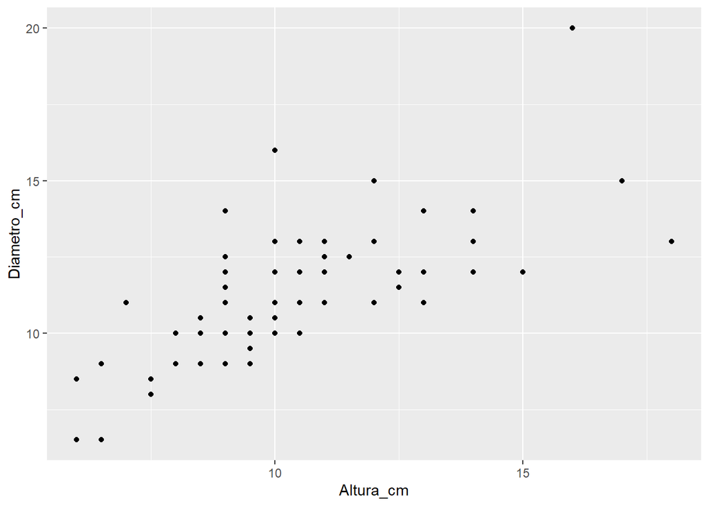

```r
ggplot(Aornatum,aes(x=Altura_cm, y = Diametro_cm)) +
  geom_point()
```

Si lo vemos con calma, tienen la base de datos con la que vamos a trabajar (Aornatum), define las variables que se van a utilizar en el eje de las $x = Altura_cm$ y el eje de las $y = Diametro_cm$ o la estética con *aes*. Finalmente le *añadimos* el tipo de visualización geométrica que queremos darle en este caso usamos puntos (geom_point) utilizando el símbolo de suma +.

ggplot tiene algunos *temas* incluidos, el gráfico default utiliza un fondo gris con líneas que no siempre es el que se usa en las ciencias biológicas, por lo general usamos un fondo blanco. Para hacer esto tenemos que añadirle el tema al final.

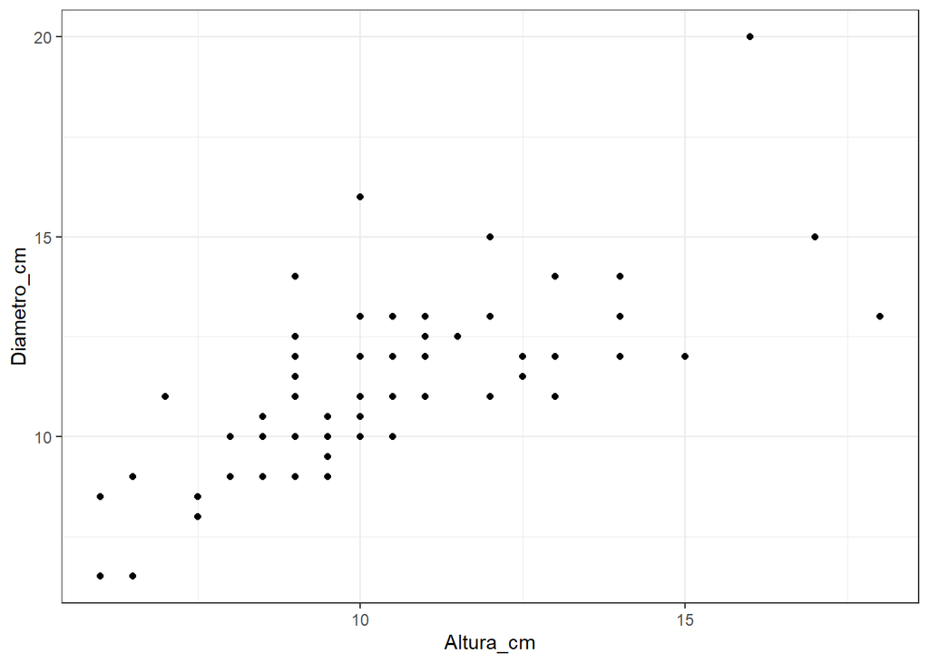

```r
ggplot(Aornatum,aes(x=Altura_cm, y = Diametro_cm)) +
  geom_point()+
  theme_bw()
```

Tambien podemos incremental el tamaño del punto

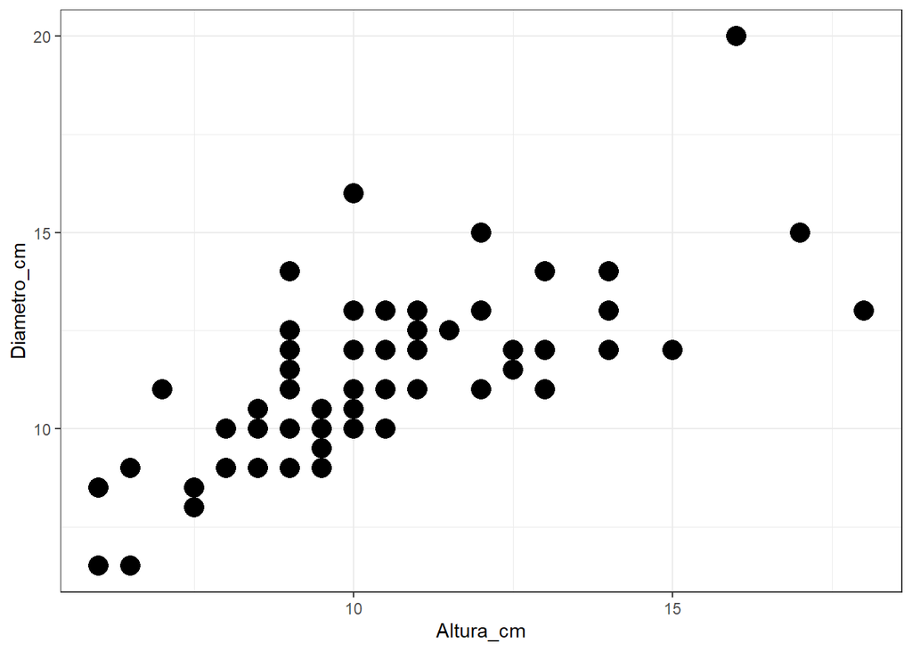

```r
ggplot(Aornatum,aes(x=Altura_cm, y = Diametro_cm)) +
  geom_point(size = 5)+
  theme_bw()
```

Para cambiar el nombre de los ejes

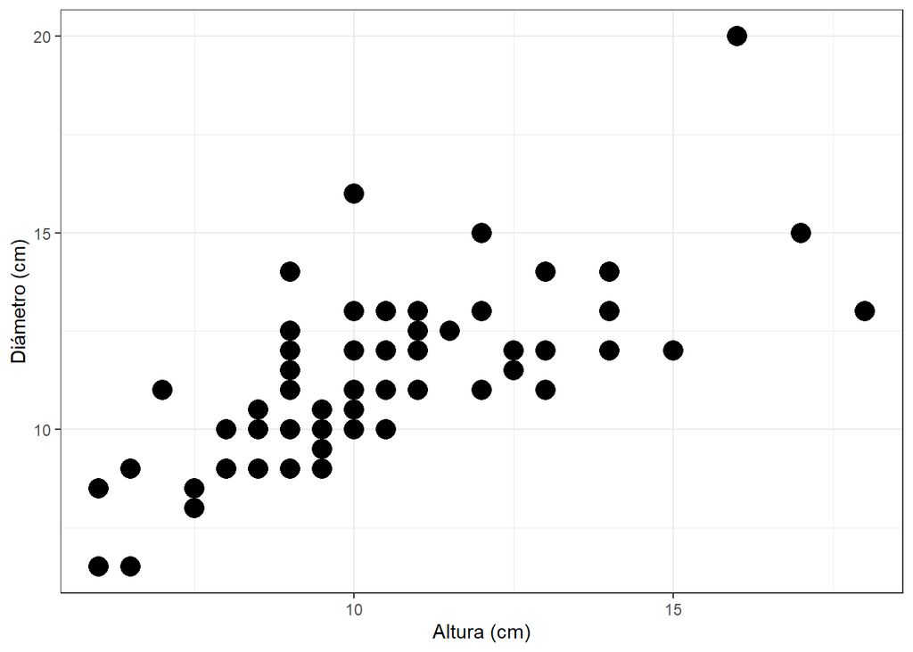

```r
ggplot(Aornatum,aes(x=Altura_cm, y = Diametro_cm)) +
  geom_point(size = 5) +
  xlab('Altura (cm)') +
  ylab('Diámetro (cm)') +
  theme_bw()
```

Si queremos asignar el color asociado al la floración lo ponemos en la estética, básicmanete diciéndole a ggplot que asigne colores con el nivel del factor.

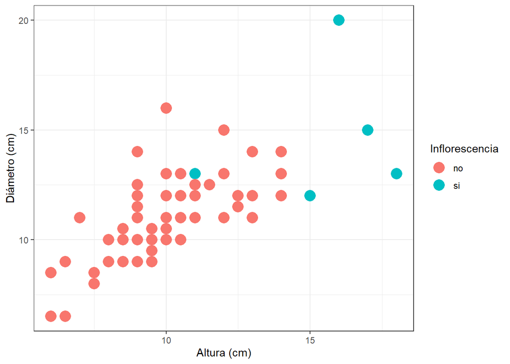

```r
ggplot(Aornatum,aes(x=Altura_cm, y = Diametro_cm, color=Inflorescencia)) +
  geom_point(size = 5) +
  xlab('Altura (cm)') +
  ylab('Diámetro (cm)') +
  theme_bw()
```

Podemos cambiar no solo el color sino la forma del punto en la estética.

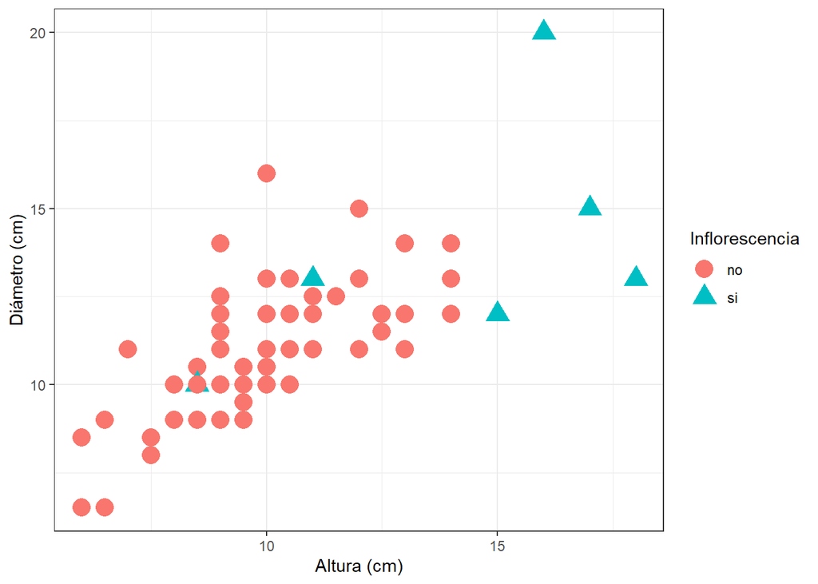

```r
ggplot(Aornatum,aes(x=Altura_cm, y = Diametro_cm, shape = Inflorescencia, color = Inflorescencia)) +
  geom_point(size = 5) +
  xlab('Altura (cm)') +
  ylab('Diámetro (cm)') +
  theme_bw()
```